# Create a large cutout of coadded images

Contact authors: Christina Williams, Melissa Graham  
Last verified to run: 2025-06-20  
LSST Science Pipelines version: Release r29.1.0  
Container Size: Large  
Targeted learning level: Intermediate

**Description:** Create a large custom `deepCoadd` cutout.

**Skills:** Identify tracts and patches and combine them into a large custom `deepCoadd` cutout.

**LSST Data Products:** deepCoadd_calexp

**Packages:** lsst.ip.diffim.GetTemplateTask, lsst.afw.geom.makeSkyWcs

**Credit:** Thanks to Aline Chu for raising in the Rubin Community Forum the issue of how to create patch- and tract-spanning cutouts. Thanks to Gregory Dubois-Felsmann and Lauren MacArthur who helped in the Forum, and John Parejko, Yusra Al-Sayyad, Tim Jenness and others for help with the LSST science pipelines.

**Get Support:** Find DP0-related documentation and resources at dp0.lsst.io. Questions are welcome as new topics in the [Support - Data Preview 0 Category](https://community.lsst.org/c/support/dp0) of the Rubin Community Forum. Rubin staff will respond to all questions posted there.

## 1. Introduction

At the moment, the image cutout service demonstrated in DP0.2 tutorial notebook 13a titled DP02_13a_Image_Cutout_SciDemo.ipynb must be passed a tract and patch, and can only create a cutout from a single patch.

This will always be a contraint for single processed visit images (PVIs, also known as `calexp`s). In the future, users will be able to request `deepCoadd` cutouts from the Rubin image cutout service which span patch and tract boundaries.

In the meantime, this tutorial demonstrates how to use the `GetTemplateTask` to create a single cutout image with contributions from multiple adjacent patches and tracts.

In the LSST Science Pipelines, `GetTemplateTask` is used to create a template image from `deepCoadd` images for a given PVI, in order to perform Difference Image Analysis.

These links provide documentation for [GetTemplateTask](https://pipelines.lsst.io/modules/lsst.ip.diffim/tasks/lsst.ip.diffim.GetTemplateTask.html) and its [run method](https://pipelines.lsst.io/py-api/lsst.ip.diffim.GetTemplateTask.html#lsst.ip.diffim.GetTemplateTask.run). To summarize, the function of this task is to build a "template" combined image from existing coadds. In the simplest case where the coadds that contribute to the assembled template image are all patches of the same tract, the WCS and bounding box of the pixel map is the same across the patches. The documentation for `GetTemplateTask` for this simple case of joining patches from a common tract says:

> *"...overlapping box regions of the input template patches are pixel by pixel copied into the assembled template image. There is no warping or pixel resampling. Pixels with no overlap of any available input patches are set to nan value and NO_DATA flagged."*

However, for the more general case where input coadds may come from different tracts, the input images have different WCS. Thus, `GetTemplateTask` will warp the coadds from different tracts onto a common projection (i.e. a newly defined WCS). This tutorial will also demonstrate how to generate the new common WCS using `makeSkyWcs`.

The `GetTemplateTask` documentation further notes:

> *"Where the tracts overlap, the resulting template image is averaged. The PSF on the template is created by combining the CoaddPsf on each template image into a meta-CoaddPsf."*

This notebook will demonstrate how to access the final data products including the `CoaddPsf` in Section 5.

**Related tutorials:** This tutorial assumes some familiarity with the following concepts. DP0.2 tutorial notebooks that demonstrate these concepts more fully are listed in parentheses. It is not necessary to run through all of these other tutorials before doing this one, but they might be useful as reference.

- the butler (04a, 04b)
- the TAP service (02)
- image display (03a, 03b)

### 1.1. Import packages

Import packages from the LSST Science Pipelines (top) and general python packages (bottom).

```python
import lsst.afw.display as afwDisplay
import lsst.geom as geom
from lsst.rsp import get_tap_service, retrieve_query
from lsst.daf.butler import Butler, CollectionType
from lsst.ip.diffim import GetTemplateTask
from lsst.afw.image import Image
from lsst.afw.geom import makeSkyWcs

import collections
import os
import matplotlib.pyplot as plt
import numpy as np
from astropy.wcs import WCS

from photutils.aperture import SkyCircularAperture
from astropy import units as u
from astropy.coordinates import SkyCoord
```

### 1.2. Define functions and parameters

Set the `afwDisplay` backend to `matplotlib`.

```python
afwDisplay.setDefaultBackend('matplotlib')
```

Instantiate the TAP service.

```python
service = get_tap_service("tap")
```

Instantiate the butler.

```python
config = 'dp02'
collection = '2.2i/runs/DP0.2'
butler = Butler(config, collections=collection)
```

## 2. Prepare to create the cutout

### 2.1. Define central coordinates and box size

Define the central coordinates and the size of the side of the desired cutout.

For this example, the coordinates 50.5265, -39.7589 are a galaxy cluster known to be near the intersection of patches and tracts, but whose extent exceeds the distance to the image edges.

The size of the cutout will be constrained by the container size selected when the Notebook Aspect session was started, because all the images that contribute to the cutout must be held in memory simultaneously and passed to `GetTemplateTask` (this will become clear in Section 3).

```python
my_ra = 50.5265
my_dec = -39.7589
box_side_deg = 0.2
```

Define the extent of the cutout in RA and Dec. Include the `cos(dec)` factor.

```python
ra1 = my_ra + 0.5 * box_side_deg / np.cos(np.radians(my_dec))
ra2 = my_ra - 0.5 * box_side_deg / np.cos(np.radians(my_dec))
dec1 = my_dec - 0.5 * box_side_deg
dec2 = my_dec + 0.5 * box_side_deg
print('ra1 = %8.4f,  ra2 = %8.4f,  delta RA = %6.3f' %
      (ra1, ra2, np.abs(ra2-ra1)))
print('dec1 = %8.4f, dec2 = %8.4f, delta Dec = %6.3f' %
      (dec1, dec2, np.abs(dec2-dec1)))
```

```
ra1 =  50.6566,  ra2 =  50.3964,  delta RA =  0.260
dec1 = -39.8589, dec2 = -39.6589, delta Dec =  0.200
```

Define corners of the cutout.

The order is: SE, SW, NW, NE, as drawn in the plot below.

```python
corners = np.asarray([[ra1, dec1], [ra2, dec1],
                      [ra2, dec2], [ra1, dec2]],
                     dtype='float')
```

Create a little plot to visualize the corners.

Note that the figure is forced to 3:2 dimensions size.

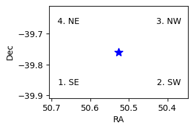

```python
fig = plt.figure(figsize=(3, 2))
plt.plot(my_ra, my_dec, '*', ms=10, color='blue')
clabels = ['1. SE', '2. SW', '3. NW', '4. NE']
for corner, clabel in zip(corners, clabels):
    plt.text(corner[0], corner[1], clabel, ha='center', va='center')
plt.gca().invert_xaxis()
plt.xlim([ra1+0.05, ra2-0.05])
plt.ylim([dec1-0.05, dec2+0.05])
plt.xlabel('RA')
plt.ylabel('Dec')
plt.show()
```

> Figure 1: A small plot of RA vs. Dec to visualize the center (blue star) and the four corners (numbered and labeled) defined by the user for the large cutout.

### 2.2. Identify the patch to use as anchor image

Use the butler to find the tract and patch within which the central coordinates of the desired cutouts are most centered.

This will be the tract and patch referred to as the "anchor image" when creating the big cutout.

```python
my_point = geom.SpherePoint(my_ra * geom.degrees,
                            my_dec * geom.degrees)
skymap = butler.get('skyMap')
tract = skymap.findTract(my_point)
patch = tract.findPatch(my_point)
anchor_tract = tract.tract_id
anchor_patch = patch.getSequentialIndex()
print('anchor tract and patch: ', anchor_tract, anchor_patch)
del my_point, skymap, tract, patch
```

```
anchor tract and patch:  3442 13
```

### 2.3. Identify additional tracts and patches

In the future, it will be possible to write ADQL statements that use the INTERSECTS functionality to identify all patches (or images) that overlap with a defined polygon.

For now, use the TAP service to search the `coaddPatches` table for images with central coordinates that indicate the patch could *potentially* overlap with the defined extent of the desired cutout.

Increase the extent of the search by the patch size to make sure no overlapping patch is missed. This may well end up identifying a few patches that do not, in the end, overlap with the extent of the desired cutout -- and that's ok.

```python
sra1 = ra1 + box_side_deg
sra2 = ra2 - box_side_deg
sdec1 = dec1 - box_side_deg
sdec2 = dec2 + box_side_deg

scorners = np.asarray([[sra1, sdec1], [sra2, sdec1],
                       [sra2, sdec2], [sra1, sdec2]],
                      dtype='float')
```

Create the TAP query.

```python
string_polygon = ""
for c, scorner in enumerate(scorners):
    s1 = str(np.round(scorner[0], 4))
    s2 = str(np.round(scorner[1], 4))
    string_polygon += s1 + ', ' + s2
    if c < 3:
        string_polygon += ', '
    del s1, s2

query = "SELECT lsst_patch,lsst_tract,s_dec,s_ra "\
        "FROM dp02_dc2_catalogs.CoaddPatches "\
        "WHERE CONTAINS(POINT('ICRS', s_ra, s_dec), "\
        "POLYGON('ICRS', "+string_polygon+"))=1"
print(query)
```

```
SELECT lsst_patch,lsst_tract,s_dec,s_ra FROM dp02_dc2_catalogs.CoaddPatches WHERE CONTAINS(POINT('ICRS', s_ra, s_dec), POLYGON('ICRS', 50.8566, -40.0589, 50.1964, -40.0589, 50.1964, -39.4589, 50.8566, -39.4589))=1
```

Run the TAP query.

```python
job = service.submit_job(query)
job.run()
job.wait(phases=['COMPLETED', 'ERROR'])
print('Job phase is', job.phase)
```

```
Job phase is COMPLETED
```

If the returned job phase was "error", uncomment the following to review the error.

```python
# job.raise_if_error()
```

Retrieve the TAP results.

```python
results = job.fetch_result().to_table()
```

Option to show the results.

```python
# results
```

Hold the tract and patch values for images that will contribute, in addition to the anchor image, to the final custom cutout in `add_tracts_and_patches`.

```python
temp = []
for result in results:
    tract = result['lsst_tract']
    patch = result['lsst_patch']
    if (tract != anchor_tract) | (patch != anchor_patch):
        temp.append([tract, patch])
add_tracts_and_patches = np.asarray(temp, dtype='int')
del temp

print('add these to the anchor patch: ')
print(add_tracts_and_patches)
```

```
add these to the anchor patch:
[[3442   19]
 [3441    7]
 [3441   14]
 [3442   20]
 [3442   12]]
```

## 3. Create the custom cutout

Define the filter of the desired custom cutout.

```python
use_filter = 'r'
```

### 3.1. Define and display the anchor image

Define the `dataId` for the anchor image.

Use the butler to retrieve the anchor image and its World Coordinate System (WCS).

```python
anchor_dataId = {'tract': anchor_tract, 'patch': anchor_patch,
                 'band': use_filter}
anchor_image = butler.get('deepCoadd_calexp', dataId=anchor_dataId)
anchor_wcs = butler.get('deepCoadd_calexp.wcs', dataId=anchor_dataId)
print(anchor_wcs)
```

```
FITS standard SkyWcs:
Sky Origin: (51.4285714286, -39.4214876033)
Pixel Origin: (13999, 13999)
Pixel Scale: 0.2 arcsec/pixel
```

Visually inspect the `anchor_image`. The below demonstration plots a circle centered at `my_ra` and `my_dec`, with diameter equal to the desired image box edge outlined above. The map indicates that the desired location is near the patch and tract edge and joining to other deepCoadds is required in order to display a contiguous image.

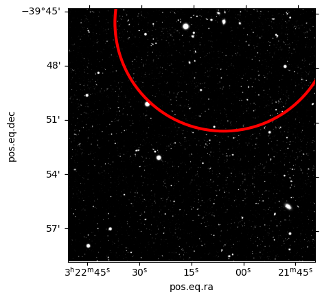

```python
radius = box_side_deg/2. * u.deg
coord = SkyCoord(ra=my_ra*u.degree, dec=my_dec*u.degree, frame='icrs')

plt.subplot(projection=WCS(anchor_image.getWcs().getFitsMetadata()))
extent = (anchor_image.getBBox().beginX, anchor_image.getBBox().endX,
          anchor_image.getBBox().beginY, anchor_image.getBBox().endY)

plt.imshow(anchor_image.image.array, vmin=.1, vmax=1, extent=extent,
           origin='lower', cmap='gray')

anchor_bbox = anchor_image.getBBox()

aperture = SkyCircularAperture(coord, r=radius)
pix_aperture = aperture.to_pixel(WCS(anchor_image.getWcs().getFitsMetadata()))
pix_aperture.plot(color='r', lw=3)
```

> Figure 2: The anchor image patch, with a partial red circle indicating that the size of the desired large cutout is bigger than a single `deepCoadd` patch.

### 3.2. Define the other images to combine

Create the arrays of `dataId`s and images to be passed to `GetTemplateTask`.

```python
all_dataIds = [anchor_dataId]
all_images = [anchor_image]
all_tracts = [anchor_tract]

for i in range(len(add_tracts_and_patches)):
    temp_tract = add_tracts_and_patches[i][0]
    temp_patch = add_tracts_and_patches[i][1]
    temp_dataId = {'tract': temp_tract, 'patch': temp_patch,
                   'band': use_filter}
    temp_image = butler.get('deepCoadd_calexp', dataId=temp_dataId)

    all_images.append(temp_image)
    all_dataIds.append(temp_dataId)
    all_tracts.append(temp_tract)

    del temp_tract, temp_patch, temp_dataId, temp_image
```

Print the `dataId`s.

```python
for dataId in all_dataIds:
    print(dataId)
```

```
{'tract': 3442, 'patch': 13, 'band': 'r'}
{'tract': np.int64(3442), 'patch': np.int64(19), 'band': 'r'}
{'tract': np.int64(3441), 'patch': np.int64(7), 'band': 'r'}
{'tract': np.int64(3441), 'patch': np.int64(14), 'band': 'r'}
{'tract': np.int64(3442), 'patch': np.int64(20), 'band': 'r'}
{'tract': np.int64(3442), 'patch': np.int64(12), 'band': 'r'}
```

### 3.3. Set up `getTemplateTask`

Define `getTemplateTask` which will enable the various images to be warped and resampled into one big cutout.

No configuration changes are needed.

```python
getTemplateTask = GetTemplateTask()
```

Build the WCS definition for the new cutout.

It is necessary to reproject the input images to a new tangent plane centered at the target and with north up. This procedure is generally applicable for any set of images, even if generating a cutout from adjacent patches within one tract (which have the same pixel grid).

The cell below defines the new WCS for the joined images across both patch and tract boundaries.

The WCS consists of 4 components.

1. The RA and Dec of the center of the image defined as `crval`.
2. The center pixel (x, y) defined as `crpix`.  
   In Section 1, the cutout area of interest is defined in `box_side_deg` as 0.2 degrees on a side (12 arcminutes). The center is defined as `box_side_deg`, converted to arcsec and then divided in half. Dividing that by the `deepCoadd` pixel scale of 0.2 arcsec/pixel results in the center pixel, in units of pixels.
3. The pixel scale, which is a 2x2 matrix defined as `cdMatrix`.  
   Note that the pixel scale of all deepCoadds are always the same, so the new WCS can simply use the one from `anchor_image`.
4. The projection of the WCS `projection`, which is defined as `TAN` (referring to a new tangent projection centered at the `crval`).

```python
crval = geom.SpherePoint(my_ra, my_dec, geom.degrees)

crpix = box_side_deg * 3600 / 2. / 0.2
crpix1 = crpix
crpix2 = crpix
crpix = geom.Point2D(crpix1, crpix2)

x = anchor_image.getWcs().getFitsMetadata()
cdMatrix = [x['CD1_1'], x['CD1_2']], [x['CD2_1'], x['CD2_2']]

projection = 'TAN'
```

Define the new WCS for the large cutout using the `makeSkyWcs` method based on the definition above.

```python
newWCS = makeSkyWcs(crpix, crval, cdMatrix, projection)
print(newWCS)
print(anchor_image.getWcs())
```

```
FITS standard SkyWcs:
Sky Origin: (50.5265000000, -39.7589000000)
Pixel Origin: (1800, 1800)
Pixel Scale: 0.2 arcsec/pixel
FITS standard SkyWcs:
Sky Origin: (51.4285714286, -39.4214876033)
Pixel Origin: (13999, 13999)
Pixel Scale: 0.2 arcsec/pixel
```

Create a bounding box for the new image.

```python
corner_SE_deg = geom.SpherePoint(corners[0][0], corners[0][1], geom.degrees)
corner_NW_deg = geom.SpherePoint(corners[2][0], corners[2][1], geom.degrees)
corner_SE_pix = newWCS.skyToPixel(corner_SE_deg)
corner_NW_pix = newWCS.skyToPixel(corner_NW_deg)

xmin = int(np.floor(corner_SE_pix[0]))
ymin = int(np.floor(corner_SE_pix[1]))
xmax = int(np.floor(corner_NW_pix[0]))
ymax = int(np.floor(corner_NW_pix[1]))

newimg_shape = Image(geom.Box2I(minimum=geom.Point2I(x=xmin, y=ymin),
                                maximum=geom.Point2I(x=xmax, y=ymax)),
                     dtype=np.float32)
newimage_bbox = newimg_shape.getBBox()
```

### 3.4. Create the big cutout image

Create the custom cutout as `newimage`.

> **Notice:** Some input patch images are skipped for not overlapping with the defined bounding box after all, as was expected (Section 2.3). The argument `physical_filter` is required to be passed, even though use of r-band was already specified above.

The identification of the patch/tract images that overlap the big cutout area of interest can be performed using the `getExposures` method of `getTemplateTask`. This method will take as input the LSST images that may overlap the desired area in the format of a `DeferredDatasetHandle`, and return a dictionary of lists containing those only of images that overlap that area. While the exclusion of non-overlapping images is done automatically by `getTemplateTask.run`, the example below shows how to use `getExposures` to identify the overlapping images.

Further information on `datasetRef` types can be found in DP0.2 Tutorial Notebook 04b.

The `getExposures` method of `getTemplateTask` is documented [here](https://pipelines.lsst.io/v/daily/py-api/lsst.ip.diffim.GetTemplateTask.html#lsst.ip.diffim.GetTemplateTask.getExposures) and requires as input a dictionary that includes at least 4 components: a list of lsst `ExposureF` objects in `DeferredDatasetHandle` format; the template bounding box for the desired big coadd; the input geometry (SkyMap) for the template exposures, and the template WCS onto which the coadds will be resampled.

The cell below demonstrates how to get a list of DeferredDatasetHandle datarefs.

```python
dI = all_dataIds[0]
dataset_refs = list(butler.query_datasets('deepCoadd', data_id=dI))
dataset_refs = set(dataset_refs)

for dI in all_dataIds[1:]:
    dr = list(butler.query_datasets('deepCoadd', data_id=dI))
    dataset_refs = dataset_refs.union(set(dr))

coadd_deferred_dataset_handle = [butler.getDeferred(dr) for dr in dataset_refs]
sky_map = butler.get("skyMap")
inputs = {"coaddExposures": coadd_deferred_dataset_handle,
          "bbox": newimage_bbox,
          "skyMap": sky_map,
          "wcs": newWCS, }
```

The cell below demonstrates how to run the `getExposures` method to identify the overlapping images.

```python
print("Collecting the patches/tracts that overlap the desired bounding box")

results = getTemplateTask.getExposures(coadd_deferred_dataset_handle,
                                       newimage_bbox, sky_map, newWCS)
```

```
lsst.getTemplate INFO: Using template input tract=3442, patch=13
```

```
lsst.getTemplate INFO: Using template input tract=3441, patch=14
```

```
lsst.getTemplate INFO: Using template input tract=3442, patch=20
```

```
lsst.getTemplate INFO: Using template input tract=3441, patch=7
```

Below, access the metadata about the overlapping exposures (noting that the output is indexed by tract). `getTemplateTask` expects the input lists of images and dataIds to be in dicts indexed on tract id.

```python
print('dictionary of dataIds for overlapping exposures:', results.dataIds)
print('dictionary of overlapping exposures:', results.coaddExposures)
```

```
dictionary of dataIds for overlapping exposures: defaultdict(<class 'list'>, {3442: [{band: 'r', skymap: 'DC2', tract: 3442, patch: 13}, {band: 'r', skymap: 'DC2', tract: 3442, patch: 20}], 3441: [{band: 'r', skymap: 'DC2', tract: 3441, patch: 14}, {band: 'r', skymap: 'DC2', tract: 3441, patch: 7}]}…
dictionary of overlapping exposures: defaultdict(<class 'list'>, {3442: [<lsst.afw.image._exposure.ExposureF object at 0x7e96bff103f0>, <lsst.afw.image._exposure.ExposureF object at 0x7e9693e39470>], 3441: [<lsst.afw.image._exposure.ExposureF object at 0x7e9693f265f0>, <lsst.afw.image._exposure.Expo…
```

Generate the big cutout image based on these overlapping exposures.

```python
newimage = getTemplateTask.run(coaddExposures=results.coaddExposures,
                               bbox=newimage_bbox,
                               wcs=newWCS, dataIds=results.dataIds,
                               physical_filter='r_sim_1.4')
```

## 4. Visualize the custom cutout

Extract metadata for the custom cutout.

```python
newimage_wcs = newimage.template.getWcs()
newimage_wcs_fmd = newimage.template.getWcs().getFitsMetadata()

newimage_extent = (newimage_bbox.beginX, newimage_bbox.endX,
                   newimage_bbox.beginY, newimage_bbox.endY)
```

### 4.1. Display with matplotlib

Compare the red circle in the larger cutout to that from the `anchor_image` in Section 3.1. The full desired area is now accessible in one single contiguous cutout.

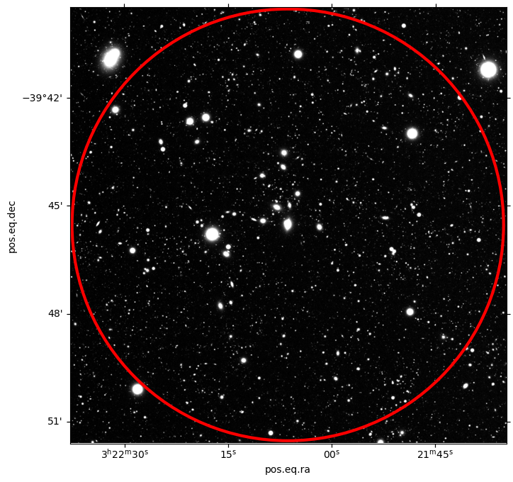

```python
fig = plt.figure(figsize=(8, 8))
plt.subplot(projection=WCS(newimage_wcs_fmd))
plt.imshow(newimage.template.image.array, vmin=0.01, vmax=0.5,
           extent=newimage_extent, origin='lower', cmap='gray')

aperture = SkyCircularAperture(coord, r=radius)
pix_aperture = aperture.to_pixel(WCS(newimage_wcs_fmd))
pix_aperture.plot(color='r', lw=3)

plt.show()
```

> Figure 3: The new image (large cutout) with a red circle marking the user-defined size.

#### 4.1.1. Draw input image boundaries

It can be useful to visualize and identify which region of the big joined image originated from which patch and tract.

Below is an example demonstrating how to identify the origin image for pixels in the big image, based on the input list of `dataIds` that were identified in Section 2.

The code runs through all of the `dataIds` of the neighboring patchs and tracts, identifies the pixel values of the image corners in the new image, and plots the rectangular regions defining the original images (each as a different color).

```
{'tract': 3442, 'patch': 13, 'band': 'r'} red
```

```
{'tract': np.int64(3442), 'patch': np.int64(19), 'band': 'r'} orange
```

```
{'tract': np.int64(3441), 'patch': np.int64(7), 'band': 'r'} yellow
```

```
{'tract': np.int64(3441), 'patch': np.int64(14), 'band': 'r'} green
```

```
{'tract': np.int64(3442), 'patch': np.int64(20), 'band': 'r'} blue
```

```
{'tract': np.int64(3442), 'patch': np.int64(12), 'band': 'r'} purple
```

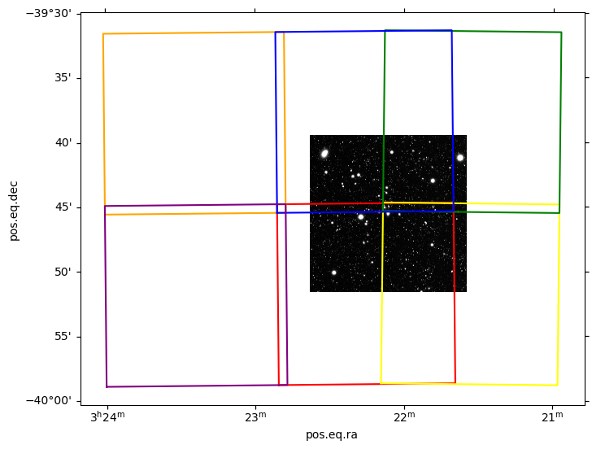

```python
fig = plt.figure(figsize=(8, 8))
plt.subplot(projection=WCS(newimage_wcs_fmd))
plt.imshow(newimage.template.image.array, vmin=0.01, vmax=0.5,
           extent=newimage_extent, origin='lower', cmap='gray')

colors = ['red', 'orange', 'yellow', 'green', 'blue', 'purple']
i = 0

for dataId in all_dataIds:
    print(dataId, colors[i])
    dataId_image = butler.get('deepCoadd_calexp', dataId=dataId)
    dataId_wcs = butler.get('deepCoadd_calexp.wcs', dataId=dataId)
    dataId_bbox = dataId_image.getBBox()

    corners2 = [dataId_wcs.pixelToSky(dataId_bbox.beginX, dataId_bbox.beginY),
                dataId_wcs.pixelToSky(dataId_bbox.beginX, dataId_bbox.endY),
                dataId_wcs.pixelToSky(dataId_bbox.endX, dataId_bbox.endY),
                dataId_wcs.pixelToSky(dataId_bbox.endX, dataId_bbox.beginY)]

    corners_dataId_sky = [geom.SpherePoint(corners2[0].getRa().asDegrees(),
                                           corners2[0].getDec().asDegrees(),
                                           geom.degrees),
                          geom.SpherePoint(corners2[1].getRa().asDegrees(),
                                           corners2[1].getDec().asDegrees(),
                                           geom.degrees),
                          geom.SpherePoint(corners2[2].getRa().asDegrees(),
                                           corners2[2].getDec().asDegrees(),
                                           geom.degrees),
                          geom.SpherePoint(corners2[3].getRa().asDegrees(),
                                           corners2[3].getDec().asDegrees(),
                                           geom.degrees)]
    corners_dataId_pix = newWCS.skyToPixel(corners_dataId_sky)

    coord_box = [[corners_dataId_pix[0].getX(), corners_dataId_pix[0].getY()],
                 [corners_dataId_pix[1].getX(), corners_dataId_pix[1].getY()],
                 [corners_dataId_pix[2].getX(), corners_dataId_pix[2].getY()],
                 [corners_dataId_pix[3].getX(), corners_dataId_pix[3].getY()]]

    # store the pixel values of the NE corner;
    # to be used to study PSF variation in Section 5
    if i == 0:
        NE_anchor_pix = np.floor(coord_box[2])

    coord_box.append(coord_box[0])  # repeat the first to create a closed loop
    xs, ys = zip(*coord_box)  # create lists of x and y values

    plt.plot(xs, ys, color=colors[i])
    i = i+1

plt.show()
```

> Figure 4: The new image, with the bounding boxes of the six individual `deepCoadd` images which were identified as potential contributors to the big cutout shown in orange, purple, blue, red, green, and yellow.

### 4.2. Display with `afwDisplay`

As an option, display the big coadd with `afwDisplay`.

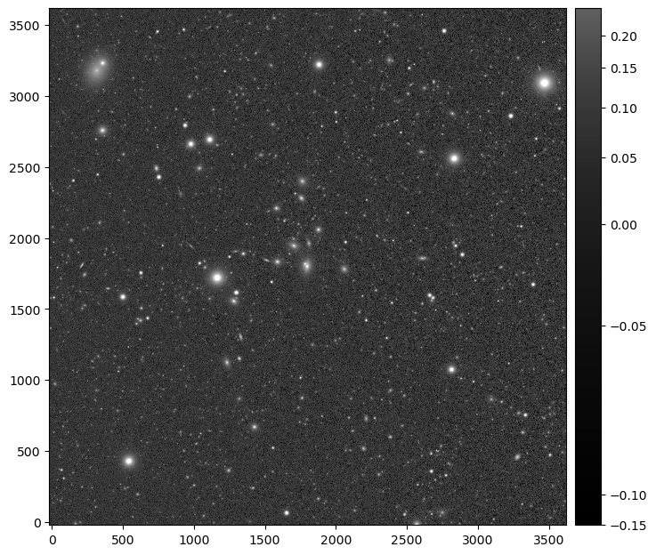

```python
fig = plt.figure(figsize=(8, 8))
display = afwDisplay.Display(frame=fig)
display.scale('asinh', 'zscale')
display.mtv(newimage.template.image)
plt.show()
```

> Figure 5: The new image, displayed in greyscale with `afwDisplay`.

### 4.3. Display with Firefly

Firefly allows for interactive image display and manipulation. See DP0.2 tutorial notebook 03b for a full demonstration of how to use Firefly within the Notebook Aspect.

Reset the `afwDisplay` backend to be Firefly and start the display. A new tab will open, containing the Firefly interface.

```python
afwDisplay.setDefaultBackend('firefly')
afw_display = afwDisplay.Display(frame=1)
```

Display the image in Firefly.

```python
afw_display.mtv(newimage.template)
```

The Firefly default is to visualize the mask plane with colors. Set the mask plane transparency to 100, fully transparent, to see only the pixel data.

```python
afw_display.setMaskTransparency(100)
```

### 4.4. Option to save as a FITS file

To save as a FITS file in the home directory, uncomment (remove the #) from all lines in the following cell and then execute it.

> **Warning:** Images can take up a lot of disk space. Save and download with caution.

```python
# username = os.environ.get('USER')
# fnm = '/home/' + username + '/my_big_cutout.fits'
# newimage.template.writeFits(fnm)
# del username, fnm
```

## 5. Accessing the PSF metadata of the new cutout

Where the tracts overlap, the pixel values are averaged to generate the resulting template image.

The point-spread function (PSF) on the template (big cutout) is created by combining the `CoaddPsf` on each template image into a meta-CoaddPsf. Thus, it is possible to extract the PSF properties from any region of the new big cutout image, in the same way it is done for the `deepCoadd` images.

Below demonstrates the way to access the PSF meta data from the template image.

More information on how to access PSF information can be found in DP0.2 tutorial notebooks 12a and 12b.

### 5.1. Compare the PSF size

Compare the size (the width; the standard deviation or $\sigma$, `sigma`) of the PSF of the original (anchor) image to that of the new (template) image for a fixed sky location: the user-defined center of the new image (`center`).

At this location, two patch images overlapped (as shown in Section 4.1.1.), so pixel data has been averaged, and some small variation is to be expected.

```python
center = geom.SpherePoint(my_ra, my_dec, geom.degrees)

anchor_info = anchor_image.getInfo()
center_pix_anchor = anchor_wcs.skyToPixel(center)
newimage_info = newimage.template.getInfo()
center_pix_newimage = newWCS.skyToPixel(center)
point_tuple = (center_pix_anchor[0], center_pix_anchor[1])
point_image = geom.Point2D(point_tuple)
anchor_psf = anchor_image.getPsf()
psf_shape = anchor_psf.computeShape(point_image)
psf_sigma_old = psf_shape.getDeterminantRadius()
print("anchor center sigma=", psf_sigma_old)

newimage_psf = newimage.template.getPsf()
point_tuple = (center_pix_newimage[0], center_pix_newimage[1])
point_image = geom.Point2D(point_tuple)
psf_shape = newimage_psf.computeShape(point_image)
psf_sigma_new = psf_shape.getDeterminantRadius()
print("newimage center sigma=", psf_sigma_new)

percent_diff = np.abs(psf_sigma_old - psf_sigma_new)/psf_sigma_new * 100
print("percent difference is ", percent_diff, "%")
```

```
anchor center sigma= 1.8159794699122793
newimage center sigma= 1.8097881058454774
percent difference is  0.3421043627596093 %
```

Next, check that the size of the PSF in the anchor image is the same as in the new image, for a location that is not averaged across multiple patches, but is warped to the new WCS.

The cell below compares the size of the PSFs at the location of the southeast corner (`corner_SE_deg` as defined in Section 2), where the PSF is derived only from the single original patch.

```python
center_pix = anchor_wcs.skyToPixel(corner_SE_deg)
point_tuple = (center_pix[0], center_pix[1])
point_image = geom.Point2D(point_tuple)
psf_shape = anchor_psf.computeShape(point_image)
psf_sigma_old = psf_shape.getDeterminantRadius()
print("anchor SE corner sigma=", psf_sigma_old)

center_pix = newWCS.skyToPixel(corner_SE_deg)
point_tuple = (center_pix[0], center_pix[1])
point_image = geom.Point2D(point_tuple)
psf_shape = newimage_psf.computeShape(point_image)
psf_sigma_new = psf_shape.getDeterminantRadius()
print("newimage SE corner sigma=", psf_sigma_new)

percent_diff = np.abs(psf_sigma_old - psf_sigma_new)/psf_sigma_new * 100
print("percent difference is ", percent_diff, "%")
```

```
anchor SE corner sigma= 1.8051753765207257
```

```
newimage SE corner sigma= 1.7968912582832737
percent difference is  0.46102501747192803 %
```

### 5.2. Spatial variation in PSF differences

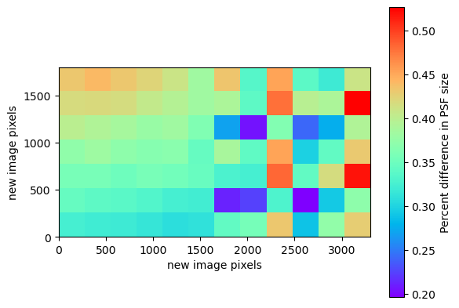

```python
NW_x = NE_anchor_pix[0]
NW_y = NE_anchor_pix[1]

SE_x = 0
SE_y = 0

x_arr = np.arange(SE_x, NW_x, 300)
y_arr = np.arange(SE_y, NW_y, 300)

PSF_diff = np.zeros((len(x_arr), len(y_arr)))

for i in range(len(x_arr)):
    for j in range(len(y_arr)):
        point_new = geom.Point2D(x_arr[i], y_arr[j])
        sigma_new = newimage_psf.computeShape(point_new).getDeterminantRadius()
        coords4anchor = newWCS.pixelToSky(x_arr[i], y_arr[j])
        point_old = geom.Point2D(anchor_wcs.skyToPixel(coords4anchor))
        sigma_old = anchor_psf.computeShape(point_old).getDeterminantRadius()
        PSF_diff[i][j] = np.abs(sigma_old - sigma_new) / sigma_new * 100

plt.imshow(PSF_diff.T, cmap='rainbow',
           extent=[np.min(x_arr), np.max(x_arr),
                   np.min(y_arr), np.max(y_arr)])

plt.colorbar(label='Percent difference in PSF size')
plt.xlabel('new image pixels')
plt.ylabel('new image pixels')
plt.show()
```